# Probability Distribution

This is about the probability distributions, gonna test some basic functions in R which are used for the generators.

Most common distribution is bell shaped/ normal distribution.

```r
?rnorm
# Generating 10 random numbers with 0 mean and 1 sd by default.
rnorm(n=10)
```

```
##  [1]  0.0397775 -0.9964616 -0.3151235 -0.4682600  0.4338323 -1.6793222
##  [7] -1.3137011  0.2451916 -2.0597817 -1.4957985
```

```r
# You can change them by passing parameters.
rnorm(n=10,mean = 100, sd = 10)
```

```
##  [1] 107.97924 106.12385  89.16188 103.69583 111.88284 103.85295  94.36883
##  [8] 118.10954 111.06063  95.81434
```

In reality, where data points are more than 100. It is not feasible to see dnorm output and inference from it. Practically you would like to generate plots to gain insights.

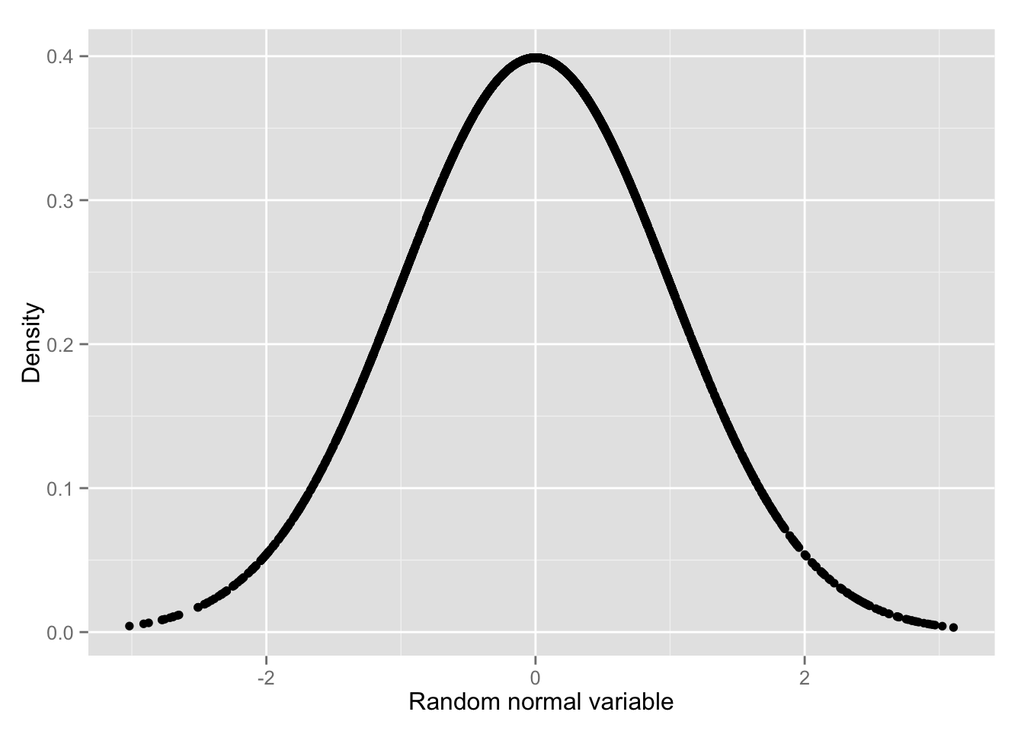

```r
randData <- rnorm(n=3000)
randDen <- dnorm(randData)
require(ggplot2)
ggplot(data.frame(x = randData, y = randDen)) + aes(x=x,y=y) +
  geom_point() + labs(x = 'Random normal variable',y='Density')
```

To calculate the density of probability distribution use dnorm.

```r
rand10 <- rnorm(10)
dnorm(rand10)
```

```
##  [1] 0.122097115 0.338143805 0.154241083 0.360322694 0.393855116
##  [6] 0.030833253 0.001510934 0.397939317 0.230240284 0.393771700
```

Similarly, pnorm calculates the distribution of the normal distribution; that is, the cumulative probability that a given number, or smaller number, occurs. by default it will left-tail.

```r
?pnorm
pnorm(10)
```

```
## [1] 1
```

```r
# a few things happen with this first line of code
# the idea is to build a ggplot2 object that we can build upon later
# that is why it is saved to p
# we take randNorm and randDensity and put them into a data.frame
# we declare the x and y axes outside of any other function
# this just gives more flexibility
# we add lines with geom_line()
# x- and y-axis labels with labs(x="x", y="Density")
p <- ggplot(data.frame(x=randData, y=randDen)) + aes(x=x, y=y) +
geom_line() + labs(x="x", y="Density")

# plotting p will print a nice distribution
# to create a shaded area under the curve we first calculate that area
# generate a sequence of numbers going from the far left to -1
neg1Seq <- seq(from=min(randData), to=-1, by=.1)

# build a data.frame of that sequence as x
# the distribution values for that sequence as y
lessThanNeg1 <- data.frame(x=neg1Seq, y=dnorm(neg1Seq))

head(lessThanNeg1)
```

```
##           x           y
## 1 -3.017614 0.004203084
## 2 -2.917614 0.005655226
## 3 -2.817614 0.007533363
## 4 -2.717614 0.009935388
## 5 -2.617614 0.012972923
## 6 -2.517614 0.016770574
```

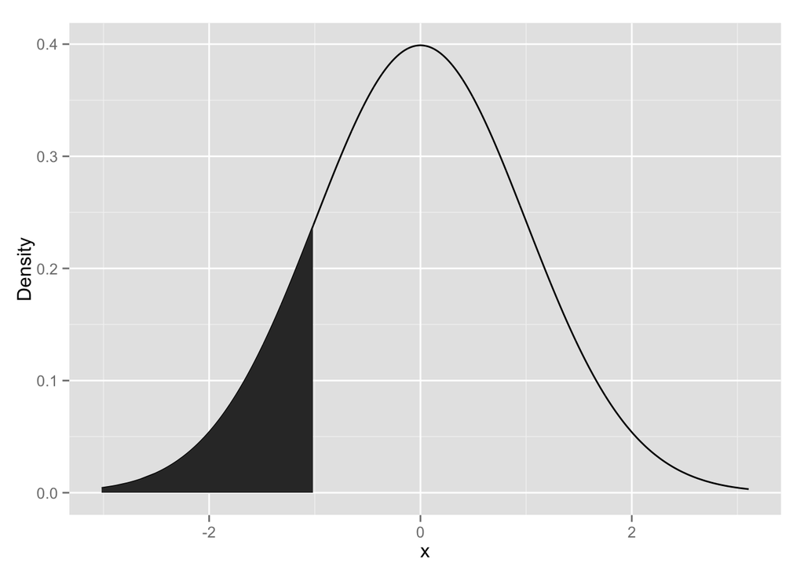

```r
# combine this with endpoints at the far left and far right
# the height is 0
lessThanNeg1 <- rbind(c(min(randData), 0), lessThanNeg1, c(max(lessThanNeg1$x), 0))

# use that shaded region as a polygon
p + geom_polygon(data=lessThanNeg1, aes(x=x, y=y))
```

```r
# create a similar sequence going from -1 to 1
neg1Pos1Seq <- seq(from=-1, to=1, by=.1)

# build a data.frame of that sequence as x
# the distribution values for that sequence as y
neg1To1 <- data.frame(x=neg1Pos1Seq, y=dnorm(neg1Pos1Seq))
head(neg1To1)
```

```
##      x         y
## 1 -1.0 0.2419707
## 2 -0.9 0.2660852
## 3 -0.8 0.2896916
## 4 -0.7 0.3122539
## 5 -0.6 0.3332246
## 6 -0.5 0.3520653
```

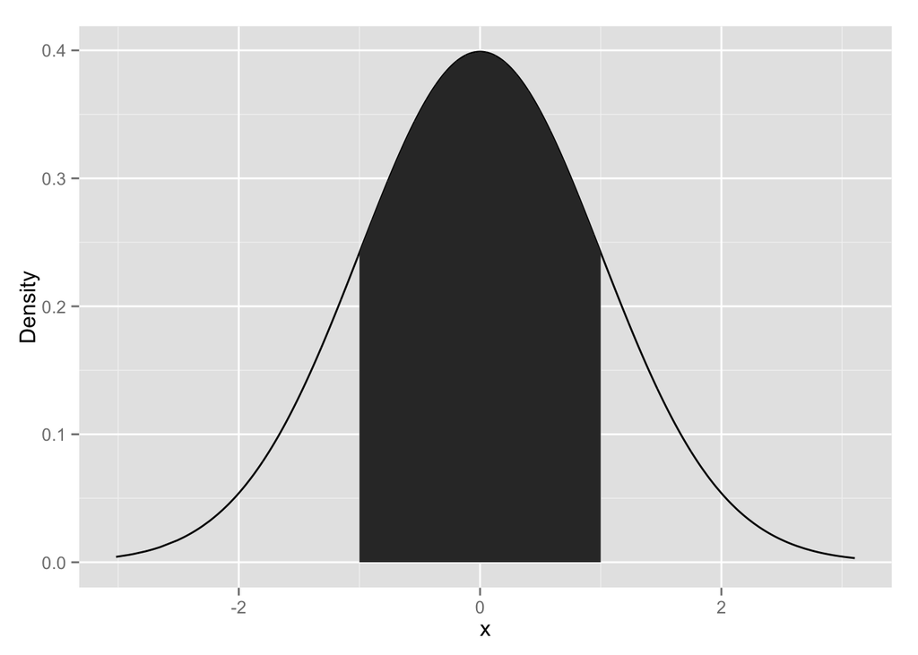

```r
neg1To1 <- rbind(c(min(neg1To1$x), 0), neg1To1,c(max(neg1To1$x), 0))
 # use that shaded region as a polygon
p + geom_polygon(data=neg1To1, aes(x=x, y=y))
```

to ge the cumulative probability a shaded region it is displayed as a single point along the y-axis. use following piece of code.

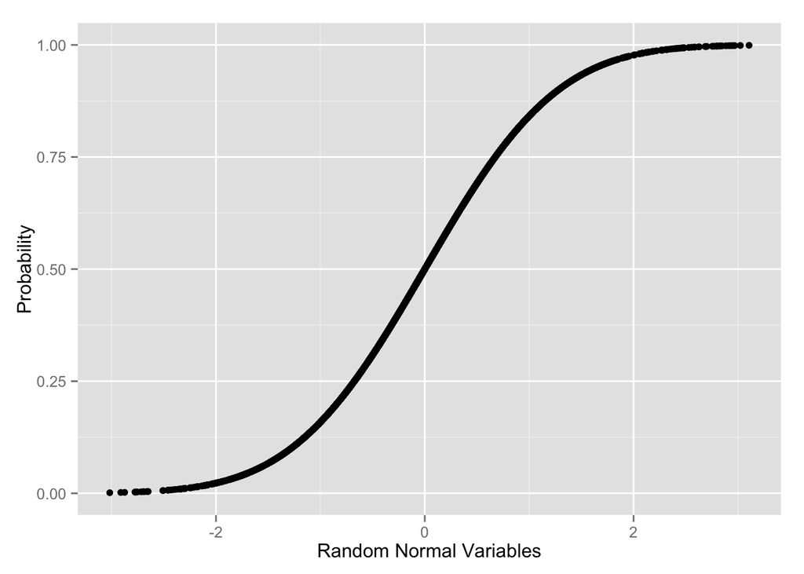

```r
randProb <- pnorm(randData)
ggplot(data.frame(x = randData,y=randProb)) + aes(x = x, y = y) +
  geom_point() + labs(x = 'Random Normal Variables', y = 'Probability')
```

The opposite of pnorm is qnorm, given commutative it returns the quantile.

```r
qnorm(pnorm(rand10))
```

```
##  [1]  1.53883072  0.57505736 -1.37862242  0.45125767 -0.16021005
##  [6]  2.26284025 -3.33948763  0.07095383  1.04851635 -0.16152675
```

```r
all.equal(rand10,qnorm(pnorm(rand10)))
```

```
## [1] TRUE
```

Poisson is another important distribution. As λ grows large the Poisson distribution begins to resemble the normal distribution.

```r
pois1 <- rpois(n=10000, lambda=1)
pois2 <- rpois(n=10000, lambda=2)
pois5 <- rpois(n=10000, lambda=5)
pois10 <- rpois(n=10000, lambda=10)
pois20 <- rpois(n=10000, lambda=20)
pois <- data.frame(Lambda.1=pois1, Lambda.2=pois2,
                       Lambda.5=pois5, Lambda.10=pois10, Lambda.20=pois20)
# load reshape2 package to melt the data to make it easier to plot
require(reshape2)
# melt the data into a long format
pois <- melt(data=pois, variable.name="Lambda", value.name="x")
# load the stringr package to help clean up the new column name
require(stringr)
# clean up the Lambda to just show the value for that lambda
pois$Lambda <- as.factor(as.numeric(str_extract(string=pois$Lambda, pattern="\\d+")))
head(pois)
```

```
##   Lambda x
## 1      1 1
## 2      1 2
## 3      1 1
## 4      1 0
## 5      1 0
## 6      1 1
```

```r
tail(pois)
```

```
##       Lambda  x
## 49995     20 26
## 49996     20 16
## 49997     20 14
## 49998     20 17
## 49999     20 22
## 50000     20 13
```

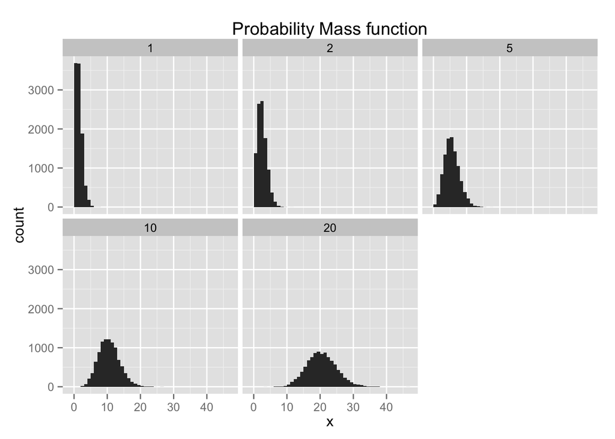

```r
ggplot(pois, aes(x= x)) + geom_histogram(binwidth = 1)+
  facet_wrap(~Lambda) + ggtitle('Probability Mass function')
```

Another, perhaps more compelling, way to visualize this convergence to normality is within overlaid density plots.

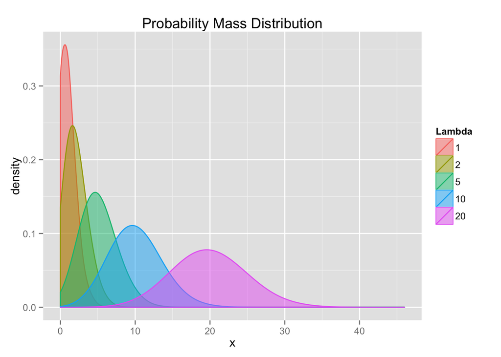

```r
ggplot(pois, aes(x = x)) +
  geom_density(aes(group = Lambda,color = Lambda, fill =Lambda), adjust = 4, alpha= 1/2) +
  scale_color_discrete() + scale_fill_discrete() + ggtitle('Probability Mass Distribution')
```